# Recitation Week 8: analysis of variance (ANOVA)

Natalie Kerr, Eric R. Scott

**Week 8 recitation** will prepare you for the next problem set (#9) by teaching you how analyse data with more than two groups, which is one constraint of the Student’s T Test. ANOVA compares the means of two or more groups that are normally distributed.

```r
#packages you will need for this notebook to run
library(car)
library(dplyr)
library(ggplot2)
library(ggformula)
```

# Warm-up exercise

## Step 1 - State your formal statistical hypotheses

Null = whether a female is fed or starved has no effect of their time to mating,

- H0: µ<sub>fed</sub> = µ<sub>starved</sub>

Alternative = a starved female will have a different time to mating than a fed female. # could also be less time

- HA: µ<sub>fed</sub> ≠ µ<sub>starved</sub>

## Step 2 - Choose an appropriate statistical test, and justify your choice. And test for its assumptions.

I initially chose a two sample, two tailed t-test to analyses these data because they were interested in whether females fed or starved have different time to mating. These data on a log scale have equal variances, but not are normally distributed. Therefore, I decided to use a Mann-Whitney U test, which is a non-parametric version of the two-sample t-test.

### Load data and visualize

```r
crickets <- read.csv("SagebrushCrickets.csv")
head(crickets)
```

|  | feedingStatus | timeToMating |
| --- | --- | --- |
| 1 | starved | 1.9 |
| 2 | starved | 2.1 |
| 3 | starved | 3.8 |
| 4 | starved | 9.0 |
| 5 | starved | 9.6 |
| 6 | starved | 13.0 |

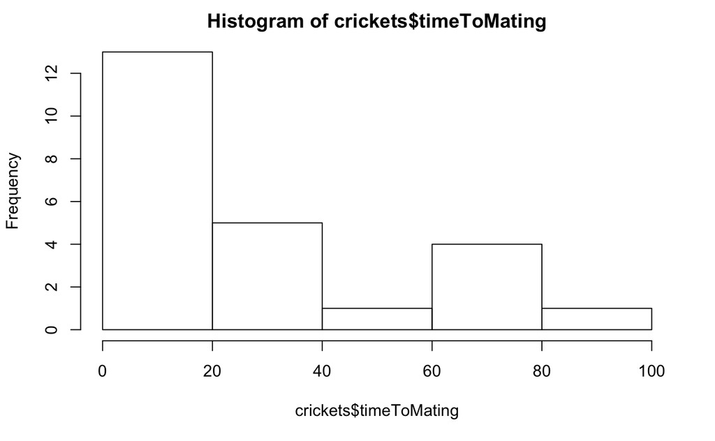

```r
hist(crickets$timeToMating)
```

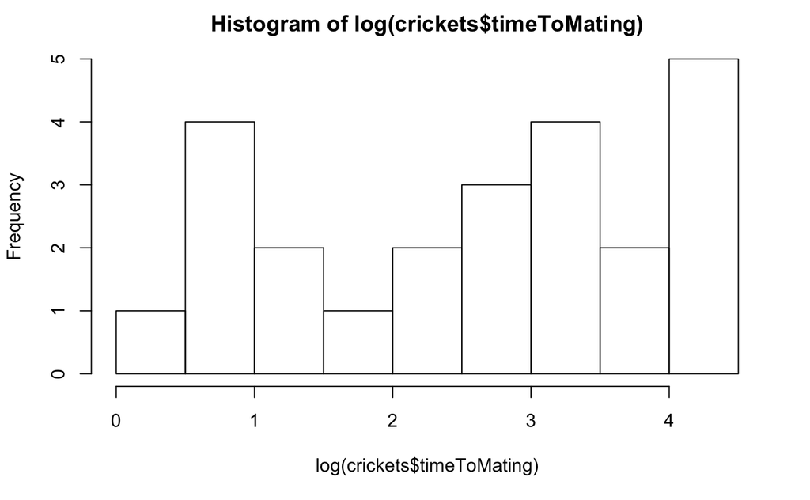

```r
hist(log(crickets$timeToMating))
```

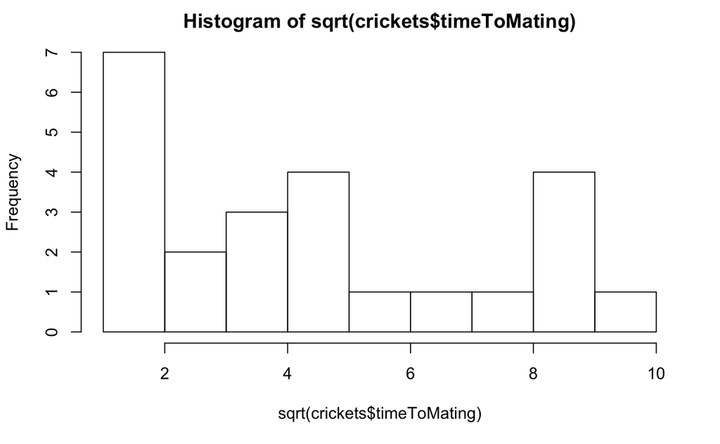

```r
hist(sqrt(crickets$timeToMating))
```

### Check assumptions of pooled variance t-test

```r
leveneTest(timeToMating ~ feedingStatus, data = crickets)
```

```
Levene's Test for Homogeneity of Variance (center = median)
      Df F value  Pr(>F)
group  1  4.5709 0.04388 *
      22
---
Signif. codes:  0 ‘***’ 0.001 ‘**’ 0.01 ‘*’ 0.05 ‘.’ 0.1 ‘ ’ 1
```

```r
leveneTest(log(timeToMating)~ feedingStatus, data=crickets) # equal variances when log transformed
```

```
Levene's Test for Homogeneity of Variance (center = median)
      Df F value Pr(>F)
group  1    2.21 0.1513
      22
```

```r
leveneTest(sqrt(timeToMating)~ feedingStatus, data=crickets)
```

```
Levene's Test for Homogeneity of Variance (center = median)
      Df F value  Pr(>F)
group  1  5.1746 0.03302 *
      22
---
Signif. codes:  0 ‘***’ 0.001 ‘**’ 0.01 ‘*’ 0.05 ‘.’ 0.1 ‘ ’ 1
```

### Check assumptions of normality

remember for t-tests to check the assumptions on the correct thing.

```r
library(dplyr)
norm <- crickets %>% #take the crickets data set, then...
  group_by(feedingStatus) %>% #group by feeding status, then...
  #create a summary table containing three columns containing p.values of the shapiro test on original and transformed data (by feeding status)
  summarise(shap.p = shapiro.test(timeToMating)$p.value,
            shap.sqrtp =shapiro.test(sqrt(timeToMating))$p.value,
            shap.logp = shapiro.test(log(timeToMating))$p.value)
norm
```

| feedingStatus | shap.p | shap.sqrtp | shap.logp |
| --- | --- | --- | --- |
| fed | 0.034554017 | 0.0589699 | 0.03404581 |
| starved | 0.001232408 | 0.2244841 | 0.72914766 |

## Step 3 - Calculate the test statistic

```r
#parametric
m1 <- t.test(log(timeToMating) ~ feedingStatus, data=crickets)
# still violates assumption of normality
m1$statistic
```

```
        t
0.7522424
```

```r
#non-parametric
m2 <- wilcox.test(timeToMating ~ feedingStatus, data=crickets) # could do non-parametric test
m2$statistic
```

```
 W
88
```

## Step 4 - Compare the calculated test statistic to a reference set

```r
m1$p.value
```

```
[1] 0.4601259
```

```r
m2$p.value
```

```
[1] 0.3607035
```

## Step 5 - Evaluate the evidence regarding H0 & make a decision

We accept null hypothesis

## Step 6 - Write a concise summary statement

Starved and fed female crickets do not differ in their time to mating (Wilcox Rank Sum test, W = 88, P = 0.361).

# Introducing ANOVA and its assumptions

So far, we’ve been running t-tests on my nectar return dataset. In these previous recitations, we were asking you to compare two colonies and their resource return (or worker body sizes), or provided you with a truncated dataset that only had two colonies. However, my demography study included *8 colonies* in total. Therefore, if we want to know if all colonies differed in their body size or nectar return. We would want to use an ANOVA.

```r
nect <- read.csv("BeeNectar.csv")
head(nect)
```

|  | Colony | BeeID | Pollen | ITS | Nectar |
| --- | --- | --- | --- | --- | --- |
| 1 | 57 | B91 | 0.00000 | 4.03 | 0.00027 |
| 2 | 41 | 838E52010B000000 | 0.00153 | 2.87 | 0.00033 |
| 3 | 41 | 798C52010B000000 | 0.02089 | 3.19 | 0.00035 |
| 4 | 57 | B58 | 0.00034 | 3.07 | 0.00063 |
| 5 | 58 | G49 | 0.00000 | 3.42 | 0.00065 |
| 6 | 32 | R24 | 0.02855 | 3.86 | 0.00114 |

```r
table(nect$Colony) # shows sample sizes in each Colony
```

```
  2  22  32  35  41  43  57  58
 63   1  45  62  81  68 169  36
```

```r
# Colony #22 had only one worker. When these colonies were relocated outside, the queen from colony #22 left and therefore no more data were collected for this colony. Subset to remove colony #22
nect.new <- subset(nect, Colony!=22)
str(nect.new) # shows the structure of the data
```

```
'data.frame':   524 obs. of  5 variables:
 $ Colony: int  57 41 41 57 58 32 58 57 57 57 ...
 $ BeeID : Factor w/ 350 levels "06AC52010B000000",..: 148 47 41 111 198 246 191 112 107 133 ...
 $ Pollen: num  0 0.00153 0.02089 0.00034 0 ...
 $ ITS   : num  4.03 2.87 3.19 3.07 3.42 3.86 4.34 3.61 3.71 4.01 ...
 $ Nectar: num  0.00027 0.00033 0.00035 0.00063 0.00065 0.00114 0.00132 0.00155 0.00196 0.00246 ...
```

```r
class(nect.new$Colony) #tells you the "class" of a particular objct (numeric, character, factor, etc.)
```

```
[1] "integer"
```

```r
nect.new$Colony <- as.factor(nect.new$Colony) #convert "Colony" to a factor
```

## Testing assumptions

ANOVA assumes homogeneity of variances and normally distributed *residuals*

### Levene’s Test

Check for homogeneity of variances

```r
leveneTest(Nectar~Colony, data = nect.new)
```

```
Levene's Test for Homogeneity of Variance (center = median)
       Df F value   Pr(>F)
group   6  3.2235 0.004062 **
      517
---
Signif. codes:  0 ‘***’ 0.001 ‘**’ 0.01 ‘*’ 0.05 ‘.’ 0.1 ‘ ’ 1
```

Doesn’t pass

### Extract residuals and check normality

Setting up the ANOVA model and extracting residuals

```r
nectar.aov <- aov(Nectar~Colony, data = nect.new) #sets up the ANOVA model
nectar.resids <- data.frame(residuals = nectar.aov$residuals) #extracts the residuals from the model into a new data frame
```

Plotting residuals

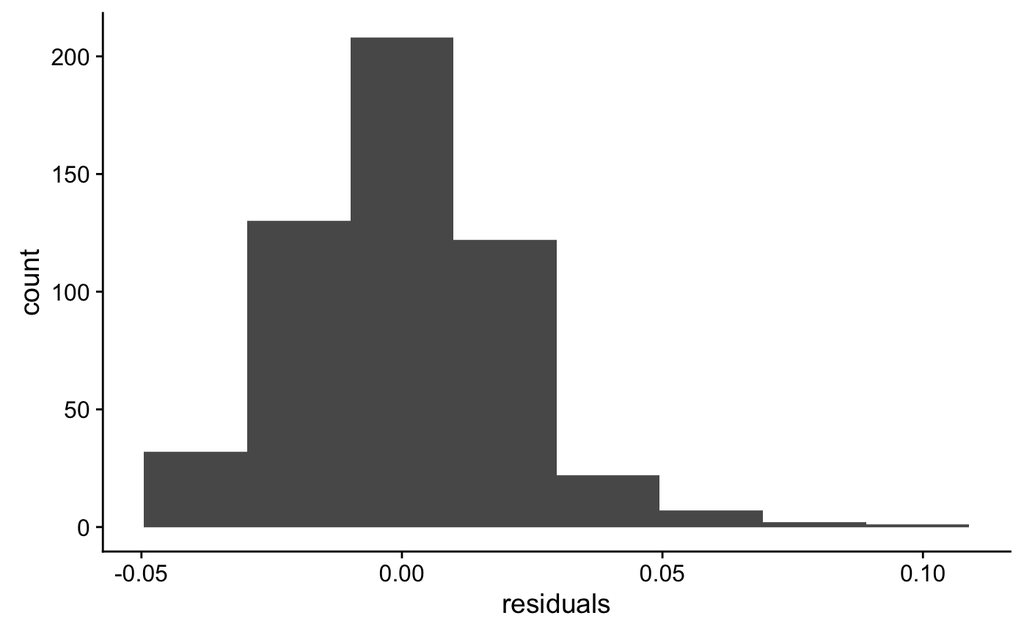

```r
ggplot(nectar.resids, aes(x = residuals)) +
  geom_histogram(bins = 8)
```

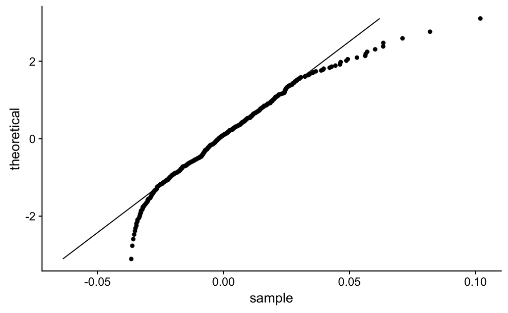

```r
ggplot(nectar.resids, aes(sample = residuals)) +
  geom_qq() +
  stat_qqline()+
  coord_flip()
```

Shapiro Test on residuals

```r
shapiro.test(nectar.aov$residuals)
```

```
    Shapiro-Wilk normality test

data:  nectar.aov$residuals
W = 0.96669, p-value = 1.582e-09
```

Very Not Normal

Let’s try some transformations

```r
log.nectar.aov <- aov(log(Nectar) ~ Colony, data = nect.new)
sqrt.nectar.aov <- aov(sqrt(Nectar) ~ Colony, data = nect.new)
```

Shapiro-Wilk’s test on transformed residuals

```r
shapiro.test(log.nectar.aov$residuals)
```

```
    Shapiro-Wilk normality test

data:  log.nectar.aov$residuals
W = 0.86601, p-value < 2.2e-16
```

```r
shapiro.test(sqrt.nectar.aov$residuals)
```

```
    Shapiro-Wilk normality test

data:  sqrt.nectar.aov$residuals
W = 0.98825, p-value = 0.000321
```

Neither transformation is a huge improvement.

Because our sample sizes are relatively large, then using ANOVA might be okay in this case.

```r
table(nect.new$Colony)
```

```
  2  32  35  41  43  57  58
 63  45  62  81  68 169  36
```

## Do the ANOVA

Get an ANOVA table with a p-value using `anova()`

```r
anova(nectar.aov)
```

```
Analysis of Variance Table

Response: Nectar
           Df   Sum Sq    Mean Sq F value  Pr(>F)
Colony      6 0.006907 0.00115125  2.6918 0.01394 *
Residuals 517 0.221114 0.00042769
---
Signif. codes:  0 ‘***’ 0.001 ‘**’ 0.01 ‘*’ 0.05 ‘.’ 0.1 ‘ ’ 1
```

Notice that R labels the ANOVA table slightly differently than your book. `Colony` is the between (among) groups variation, but the name will be whatever your factor is. `Residuals` are the same as Error or Within-Group variation.

## Non-Parametric Kruskal Wallis

Kruskal-Wallis is a non parametric equivalent to ANOVA

```r
kruskal.test(Nectar ~ Colony, data = nect.new)
```

```
    Kruskal-Wallis rank sum test

data:  Nectar by Colony
Kruskal-Wallis chi-squared = 17.547, df = 6, p-value = 0.007471
```

# Exercise 1: Circadian

**Description** - comparing phase shift in the circadian rhythm of melatonin production in participants given alternative light treatments.

**Question** - Conduct the six step procedure for hypothesis testing for this particular dataset. When selecting the appropriate test to analyse your data (Step 2), please also determine whether your data conforms to assumptions of normality given your test assumes normally distributed data. Then after the six steps, plot your data appropriately.

## Step 1 - State your formal statistical hypotheses

Null = the phase shifts in the circadian rhythm of melatonin production does not differ among light treatments, H0: µ_control = µ_eye = µ_knee Alternative = the phase shifts in the circadian rhythm of melatonin production does differ among light treatments HA: at least one mean is different

## Step 2 - Choose an appropriate statistical test, and justify your choice. And test for its assumptions.

I choose analsis of variance (ANOVA) to analyses these data because they were interested in whether light regime alters the phase shift of melatonin production. These data are normally distributed and all groups have equal variances.

```r
#read in data
cir <- read.csv("CircadianShift.csv")
head(cir)
```

|  | treatment | shift |
| --- | --- | --- |
| 1 | control | 0.53 |
| 2 | control | 0.36 |
| 3 | control | 0.20 |
| 4 | control | -0.37 |
| 5 | control | -0.60 |
| 6 | control | -0.64 |

Tests assumption of homogeneity of variances

```r
leveneTest(shift~treatment, data = cir)
```

```
Levene's Test for Homogeneity of Variance (center = median)
      Df F value Pr(>F)
group  2  0.1586 0.8545
      19
```

Set up ANOVA model and check normality

```r
cir.aov <- aov(shift~treatment, data = cir)
shapiro.test(cir.aov$residuals)
```

```
    Shapiro-Wilk normality test

data:  cir.aov$residuals
W = 0.95893, p-value = 0.468
```

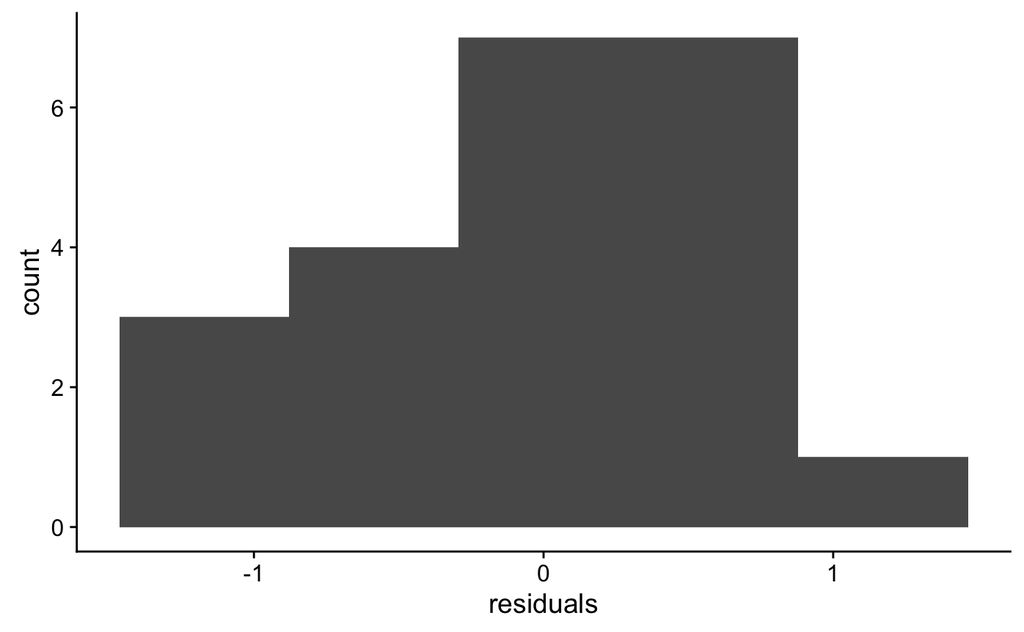

```r
cir.aov.resids <- data.frame(residuals = cir.aov$residuals)
ggplot(cir.aov.resids, aes(x = residuals)) +
  geom_histogram(bins = 5)
```

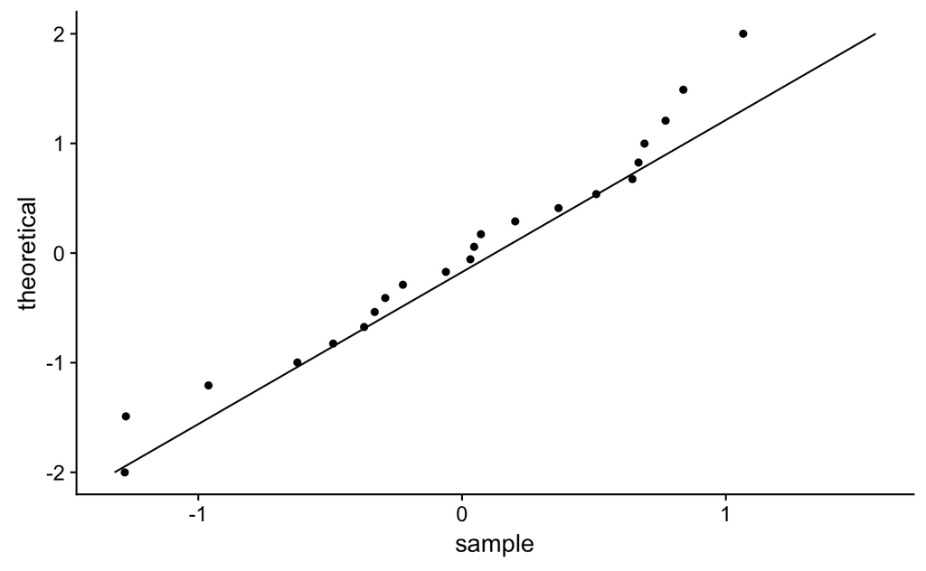

```r
ggplot(cir.aov.resids, aes(sample = residuals)) +
  geom_qq() +
  stat_qqline() +
  coord_flip()
```

Looks good

## Step 3 - Calculate the test statistic

```r
anova(cir.aov)
```

```
Analysis of Variance Table

Response: shift
          Df Sum Sq Mean Sq F value   Pr(>F)
treatment  2 7.2245  3.6122  7.2894 0.004472 **
Residuals 19 9.4153  0.4955
---
Signif. codes:  0 ‘***’ 0.001 ‘**’ 0.01 ‘*’ 0.05 ‘.’ 0.1 ‘ ’ 1
```

F = 7.2894

## Step 4 - Compare the calculated test statistic to a reference set

p = 0.0045

*Step 5* - Evaluate the evidence regarding H0 & make a decision

We reject the null hypothesis

*Step 6* - Write a concise summary statement

Light treatment significantly alters the phase shift in the circadian rhythm of melatonin production in patients (one-way ANOVA; F = 7.289; df = 2,19; P = 0.004).

## Plot data

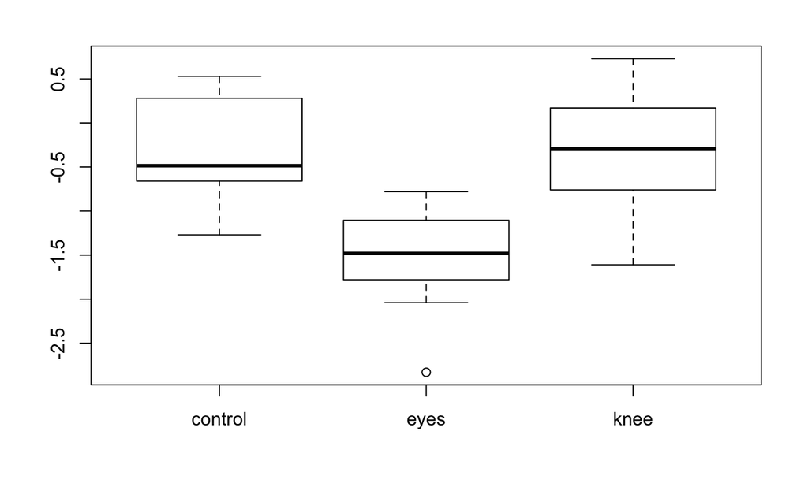

```r
# Boxplot
boxplot(shift ~ treatment, data=cir)
```

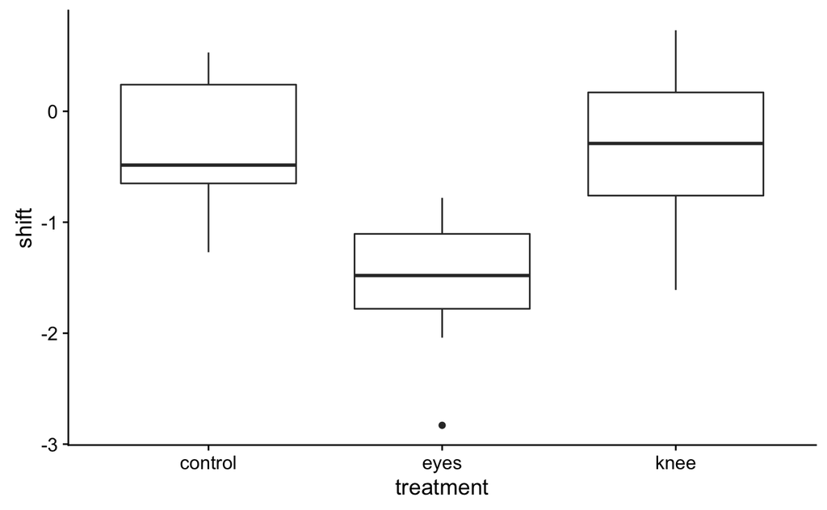

```r
## With ggplot2
ggplot(cir, aes(x = treatment, y = shift)) +
  geom_boxplot()
```

Advanced plotting

```r
cir$GroupNum <- as.integer(cir$treatment) # create a new column in our dataset called "GroupNum" that is a numeric representation of treatment column
stats <- cir %>%   #take the "cir" data set then...
  group_by(treatment) %>%   # group it by treatment, then...
  summarise(mean = mean(shift),  # create a summary table with the mean and SEM
            se = sd(shift)/length(n()))
with(cir, plot(shift ~ GroupNum, xaxt="n", ylim=c(-2.5,2.5), xlim=c(0.5, 3.5), xlab="Treatment", ylab="Circadian shift"))
axis(1, at=c(1,2,3), labels=c("Control","Eyes", "Knees"))
```

```r
arrows(c(1.1,2.1,3.1), stats$mean + stats$se, c(1.1,2.1,3.1), stats$mean - stats$se, angle=90, code=3, lwd=1)
points(c(1.1,2.1,3.1), stats$mean, pch=19, col="black")
```

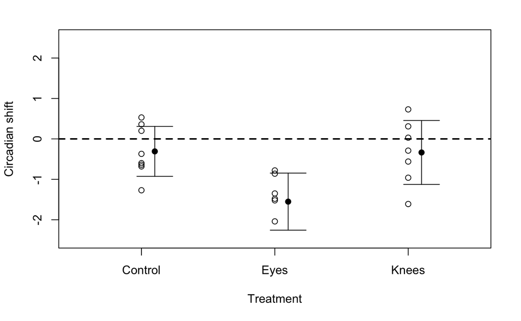

```r
abline(h=0, lwd=2, lty=2)
```